# PCFL 2021: Week 8 wrap-up

We’re now over halfway through our regular season! Playoffs start in seven weeks.

### Last week’s games

| Away | Away points | Home | Home points | Predicted result |
| --- | --- | --- | --- | --- |
| The Sophomores TSoph | 125.96 | The G.O.A.T. | 80.32 | The Sophomores TSoph (+40.6) |
| Southern Sharks | 90.82 | Athens Team Sasquatch | 121.36 | Athens Team Sasquatch (+10.83) |
| Georgia Peanuts | 102.62 | Jumpin’ Jaheims | 78.90 | Georgia Peanuts (+14.99) |
| KC Gophers | 81.20 | Pigskin on the Gridiron | 108.56 | Pigskin on the Gridiron (+12.53) |
| Middle Earth Hangry Hobbits | 102.45 | Captain Clairvoyant | 92.60 | Captain Clairvoyant (+10.46) |

Last week’s game of the week was Sharks vs. Sasquatch, and Robbie got the best in this one, scoring 121 points against Sarah’s 90. That point total was second only to The Sophomores, who rolled to a decisive win over the GOAT. It was a down week for points across the board, but those two stood out.

In other action, the Peanuts stayed boiling hot, beating Jumpin’ Jaheims. Richard and Scott also bested Christine and Brian.

The betting line was 4-1 last week in outcomes, missing only Brian’s loss to Scott.

#### Best performing players

Here’s last week’s **10 best performing players.**

| Player | Points | Team |
| --- | --- | --- |
| Josh Allen | 29.46 | Athens Team Sasquatch |
| Michael Carter | 27.70 | Southern Sharks |
| A.J. Brown | 27.50 | Southern Sharks |
| Michael Pittman Jr. | 25.60 | Pigskin on the Gridiron |
| Tom Brady | 25.20 | Captain Clairvoyant |
| Matthew Stafford | 24.20 | Middle Earth Hangry Hobbits |
| Chris Godwin | 24.00 | The Sophomores TSoph |
| Joe Mixon | 23.10 | The Sophomores TSoph |
| Amari Cooper | 22.20 | Southern Sharks |
| Darrell Henderson Jr. | 21.80 | KC Gophers |

The Sharks didn’t win, but they did end up with three of the top 10 players this week with Michael Carter, A.J. Brown, and Amari Cooper. The Sophomores were the only other team with more than one player listed.

Sad news this week about Derrick Henry, a fixture on this top ten board for the Hobbits and now out for the season with a foot injury.

#### Best addition and top bench

There were 15 players added last week. Which was the **best new addition**?

| Date added | Name | Points | Team |
| --- | --- | --- | --- |
| 2021-10-31 | Michael Carter | 27.70 | Southern Sharks |
| 2021-10-27 | Cole Beasley | 16.00 | Georgia Peanuts |
| 2021-10-28 | Randall Cobb | 15.00 | Georgia Peanuts |
| 2021-10-31 | Teddy Bridgewater | 12.62 | The G.O.A.T. |
| 2021-10-27 | Greg Joseph | 12.00 | Georgia Peanuts |
| 2021-10-28 | Greg Zuerlein | 7.00 | Southern Sharks |
| 2021-10-28 | Christian Kirk | 6.60 | The G.O.A.T. |
| 2021-10-27 | Zach Ertz | 6.20 | Pigskin on the Gridiron |
| 2021-10-28 | Mason Crosby | 6.00 | The Sophomores TSoph |
| 2021-10-27 | Sterling Shepard | 4.50 | Pigskin on the Gridiron |
| 2021-10-27 | Cole Kmet | 3.90 | Georgia Peanuts |
| 2021-10-27 | Samaje Perine | 2.60 | Georgia Peanuts |
| 2021-10-27 | Bengals D/ST | 1.00 | Southern Sharks |
| 2021-10-27 | Marquez Valdes-Scantling | 0.00 | Georgia Peanuts |
| 2021-10-27 | Bears D/ST | -6.00 | Athens Team Sasquatch |

Michael Carter was a big pickup this week for the Sharks. Cole Beasley and Randall Cobb were two fill-in WRs for me. Robbie should have known better than to trust the Bears defense.

Who won the **best scoring bench** award last week?

| Team | Points |
| --- | --- |
| Southern Sharks | 109.76 |
| Middle Earth Hangry Hobbits | 79.58 |
| Pigskin on the Gridiron | 70.80 |
| Jumpin’ Jaheims | 68.14 |
| The Sophomores TSoph | 61.70 |
| Athens Team Sasquatch | 56.56 |
| KC Gophers | 33.64 |
| The G.O.A.T. | 32.66 |
| Captain Clairvoyant | 32.04 |
| Georgia Peanuts | 22.30 |

The Southern Sharks OWNED this category this week. Sarah’s bench outscored *eight* of our ten team’s starting lineups.

### League standings and season stats

Here’s a look at the current standings.

| Team | Division | W | L | Points scored | Points allowed | Points rank | Playoff rank |
| --- | --- | --- | --- | --- | --- | --- | --- |
| The Sophomores TSoph | Hot Dish | 6 | 2 | 989.36 | 863.35 | 2 | 1 |
| Pigskin on the Gridiron | Grits | 6 | 2 | 939.92 | 881.04 | 4 | 2 |
| Athens Team Sasquatch | Grits | 5 | 3 | 1000.59 | 957.72 | 1 | 3 |
| Captain Clairvoyant | Grits | 5 | 3 | 903.90 | 863.88 | 6 | 4 |
| Georgia Peanuts | Hot Dish | 5 | 3 | 870.95 | 842.67 | 7 | 5 |
| Middle Earth Hangry Hobbits | Hot Dish | 4 | 4 | 941.49 | 872.88 | 3 | 6 |
| Southern Sharks | Hot Dish | 3 | 5 | 918.16 | 969.00 | 5 | 7 |
| Jumpin’ Jaheims | Grits | 3 | 5 | 851.45 | 925.09 | 8 | 8 |
| KC Gophers | Hot Dish | 2 | 6 | 795.52 | 890.54 | 9 | 9 |
| The G.O.A.T. | Grits | 1 | 7 | 739.92 | 885.09 | 10 | 10 |

Here’s our current awards leaders from these standings:

- Yellow shirt (most points): Team Sasquatch
- D-FENCE (least points allowed): Georgia Peanuts *new*
- Tough luck (points rank - playoff rank): Hangry Hobbits *new*–now third in points but only sixth in the rankings
- Lucky ducks (playoff rank - points rank): We’ve got a three team tie here this week: Pigskin on the Gridiron (4th in points, 2nd in standings), Captain Clairfoyant (6th and 4th), and Peanuts (7th and 5th).

Here’s a list of the **top five scoring performances** so far this season.

| Team | Week | Points scored | Result |
| --- | --- | --- | --- |
| Georgia Peanuts | 5 | 158.97 | W |
| The Sophomores TSoph | 4 | 158.62 | W |
| Athens Team Sasquatch | 5 | 149.80 | W |
| The G.O.A.T. | 4 | 149.52 | W |
| KC Gophers | 1 | 149.28 | W |

No new entries this week.

### Here’s a look at the **points trendline** for each team.

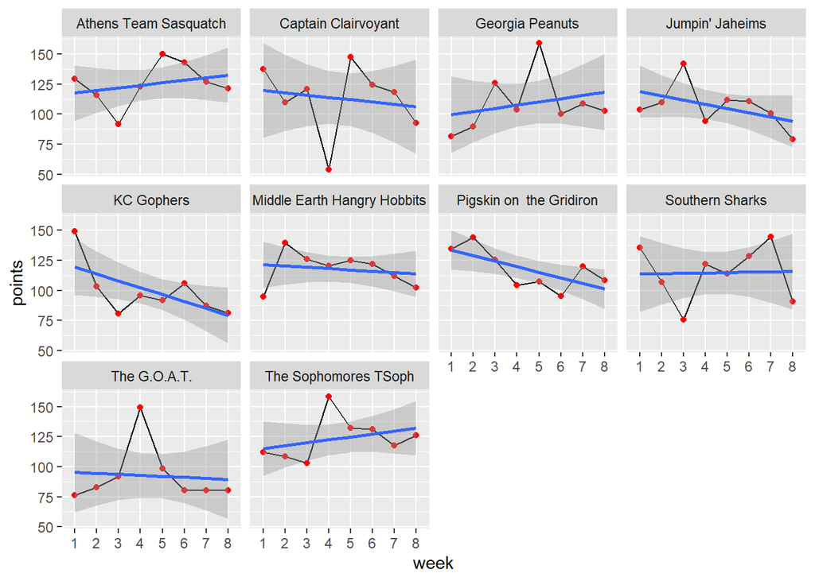

Almost everyone besides the Sophomores were either the same or lower this week compared to last. Bye weeks and injuries will do that.

### If the season ended today…

Our playoff teams would be Erin/Trav, Richard, Robbie, and Brian. Our last place finisher would be Jacob. On the edge, the Peanuts lose out on the last playoff spot by tiebreaker/points. The Hobbits are one game out, and both the Sharks and Jaheims are two games back.

### Next week’s preview

| Away team | Last 3 wks avg (away) | Home team | Last 3 wks avg (home) | Line |
| --- | --- | --- | --- | --- |
| The G.O.A.T. | 80.37 | Southern Sharks | 121.32 | Southern Sharks (+40.95) |
| The Sophomores TSoph | 124.94 | Georgia Peanuts | 103.85 | The Sophomores TSoph (+21.09) |
| Captain Clairvoyant | 111.74 | Athens Team Sasquatch | 130.40 | Athens Team Sasquatch (+18.66) |
| Middle Earth Hangry Hobbits | 111.98 | KC Gophers | 91.47 | Middle Earth Hangry Hobbits (+20.51) |
| Pigskin on the Gridiron | 107.99 | Jumpin’ Jaheims | 96.72 | Pigskin on the Gridiron (+11.27) |

It’s a rematch next week between the Peanuts and Sophomores. I beat Erin and Trav last time around, but the numbers are not looking good this week. Past champions Brian and Robbie face off. The Hobbits and Gophers battle for the below ground title, and Jacob tries to get back on track against Sarah. Lastly, the closest game on paper this week is Richard vs. Evan.

Good luck, y’all! (And remember to check your byes!)